# Optimal Treatment Analysis

## Outcome Variable

**Outcome Variable:** ever_wasted

## Predictor Variables

**Intervention Variable:** mwtkg

**Adjustment Set:**

- arm
- W_mage
- meducyrs
- feducyrs
- single
- brthmon
- W_parity
- delta_W_mage
- delta_meducyrs
- delta_feducyrs
- delta_single
- delta_brthmon
- delta_W_parity

## Stratifying Variables

The analysis was stratified on these variable(s):

- agecat
- studyid
- country

## Data Summary

| agecat | studyid | country | mwtkg | ever_wasted | n_cell | n |
| --- | --- | --- | --- | --- | --- | --- |
| 0-24 months | ki0047075b-MAL-ED | BANGLADESH | >=58 kg | 0 | 39 | 254 |
| 0-24 months | ki0047075b-MAL-ED | BANGLADESH | >=58 kg | 1 | 9 | 254 |
| 0-24 months | ki0047075b-MAL-ED | BANGLADESH | <52 kg | 0 | 97 | 254 |
| 0-24 months | ki0047075b-MAL-ED | BANGLADESH | <52 kg | 1 | 65 | 254 |
| 0-24 months | ki0047075b-MAL-ED | BANGLADESH | [52-58) kg | 0 | 33 | 254 |
| 0-24 months | ki0047075b-MAL-ED | BANGLADESH | [52-58) kg | 1 | 11 | 254 |
| 0-24 months | ki0047075b-MAL-ED | BRAZIL | >=58 kg | 0 | 132 | 221 |
| 0-24 months | ki0047075b-MAL-ED | BRAZIL | >=58 kg | 1 | 11 | 221 |
| 0-24 months | ki0047075b-MAL-ED | BRAZIL | <52 kg | 0 | 40 | 221 |
| 0-24 months | ki0047075b-MAL-ED | BRAZIL | <52 kg | 1 | 2 | 221 |
| 0-24 months | ki0047075b-MAL-ED | BRAZIL | [52-58) kg | 0 | 30 | 221 |
| 0-24 months | ki0047075b-MAL-ED | BRAZIL | [52-58) kg | 1 | 6 | 221 |
| 0-24 months | ki0047075b-MAL-ED | INDIA | >=58 kg | 0 | 33 | 242 |
| 0-24 months | ki0047075b-MAL-ED | INDIA | >=58 kg | 1 | 9 | 242 |
| 0-24 months | ki0047075b-MAL-ED | INDIA | <52 kg | 0 | 66 | 242 |
| 0-24 months | ki0047075b-MAL-ED | INDIA | <52 kg | 1 | 84 | 242 |
| 0-24 months | ki0047075b-MAL-ED | INDIA | [52-58) kg | 0 | 28 | 242 |
| 0-24 months | ki0047075b-MAL-ED | INDIA | [52-58) kg | 1 | 22 | 242 |
| 0-24 months | ki0047075b-MAL-ED | NEPAL | >=58 kg | 0 | 67 | 238 |
| 0-24 months | ki0047075b-MAL-ED | NEPAL | >=58 kg | 1 | 13 | 238 |
| 0-24 months | ki0047075b-MAL-ED | NEPAL | <52 kg | 0 | 39 | 238 |
| 0-24 months | ki0047075b-MAL-ED | NEPAL | <52 kg | 1 | 37 | 238 |
| 0-24 months | ki0047075b-MAL-ED | NEPAL | [52-58) kg | 0 | 63 | 238 |
| 0-24 months | ki0047075b-MAL-ED | NEPAL | [52-58) kg | 1 | 19 | 238 |
| 0-24 months | ki0047075b-MAL-ED | PERU | >=58 kg | 0 | 96 | 290 |
| 0-24 months | ki0047075b-MAL-ED | PERU | >=58 kg | 1 | 8 | 290 |
| 0-24 months | ki0047075b-MAL-ED | PERU | <52 kg | 0 | 102 | 290 |
| 0-24 months | ki0047075b-MAL-ED | PERU | <52 kg | 1 | 13 | 290 |
| 0-24 months | ki0047075b-MAL-ED | PERU | [52-58) kg | 0 | 66 | 290 |
| 0-24 months | ki0047075b-MAL-ED | PERU | [52-58) kg | 1 | 5 | 290 |

[output cut: 252 more lines]

The following strata were considered:

- agecat: 0-24 months, studyid: ki0047075b-MAL-ED, country: BANGLADESH
- agecat: 0-24 months, studyid: ki0047075b-MAL-ED, country: BRAZIL
- agecat: 0-24 months, studyid: ki0047075b-MAL-ED, country: INDIA
- agecat: 0-24 months, studyid: ki0047075b-MAL-ED, country: NEPAL
- agecat: 0-24 months, studyid: ki0047075b-MAL-ED, country: PERU
- agecat: 0-24 months, studyid: ki0047075b-MAL-ED, country: SOUTH AFRICA
- agecat: 0-24 months, studyid: ki0047075b-MAL-ED, country: TANZANIA, UNITED REPUBLIC OF
- agecat: 0-24 months, studyid: ki1000304b-SAS-CompFeed, country: INDIA
- agecat: 0-24 months, studyid: ki1017093-NIH-Birth, country: BANGLADESH
- agecat: 0-24 months, studyid: ki1017093b-PROVIDE, country: BANGLADESH
- agecat: 0-24 months, studyid: ki1017093c-NIH-Crypto, country: BANGLADESH
- agecat: 0-24 months, studyid: ki1066203-TanzaniaChild2, country: TANZANIA, UNITED REPUBLIC OF
- agecat: 0-24 months, studyid: ki1112895-iLiNS-Zinc, country: BURKINA FASO
- agecat: 0-24 months, studyid: ki1119695-PROBIT, country: BELARUS
- agecat: 0-24 months, studyid: ki1126311-ZVITAMBO, country: ZIMBABWE
- agecat: 0-24 months, studyid: ki1148112-LCNI-5, country: MALAWI
- agecat: 0-6 months, studyid: ki0047075b-MAL-ED, country: BANGLADESH
- agecat: 0-6 months, studyid: ki0047075b-MAL-ED, country: BRAZIL
- agecat: 0-6 months, studyid: ki0047075b-MAL-ED, country: INDIA
- agecat: 0-6 months, studyid: ki0047075b-MAL-ED, country: NEPAL
- agecat: 0-6 months, studyid: ki0047075b-MAL-ED, country: PERU
- agecat: 0-6 months, studyid: ki0047075b-MAL-ED, country: SOUTH AFRICA
- agecat: 0-6 months, studyid: ki0047075b-MAL-ED, country: TANZANIA, UNITED REPUBLIC OF
- agecat: 0-6 months, studyid: ki1000304b-SAS-CompFeed, country: INDIA
- agecat: 0-6 months, studyid: ki1017093-NIH-Birth, country: BANGLADESH
- agecat: 0-6 months, studyid: ki1017093b-PROVIDE, country: BANGLADESH
- agecat: 0-6 months, studyid: ki1017093c-NIH-Crypto, country: BANGLADESH
- agecat: 0-6 months, studyid: ki1066203-TanzaniaChild2, country: TANZANIA, UNITED REPUBLIC OF
- agecat: 0-6 months, studyid: ki1119695-PROBIT, country: BELARUS
- agecat: 0-6 months, studyid: ki1126311-ZVITAMBO, country: ZIMBABWE
- agecat: 0-6 months, studyid: ki1148112-LCNI-5, country: MALAWI
- agecat: 6-24 months, studyid: ki0047075b-MAL-ED, country: BANGLADESH
- agecat: 6-24 months, studyid: ki0047075b-MAL-ED, country: BRAZIL
- agecat: 6-24 months, studyid: ki0047075b-MAL-ED, country: INDIA
- agecat: 6-24 months, studyid: ki0047075b-MAL-ED, country: NEPAL
- agecat: 6-24 months, studyid: ki0047075b-MAL-ED, country: PERU
- agecat: 6-24 months, studyid: ki0047075b-MAL-ED, country: SOUTH AFRICA
- agecat: 6-24 months, studyid: ki0047075b-MAL-ED, country: TANZANIA, UNITED REPUBLIC OF
- agecat: 6-24 months, studyid: ki1000304b-SAS-CompFeed, country: INDIA
- agecat: 6-24 months, studyid: ki1017093-NIH-Birth, country: BANGLADESH
- agecat: 6-24 months, studyid: ki1017093b-PROVIDE, country: BANGLADESH
- agecat: 6-24 months, studyid: ki1017093c-NIH-Crypto, country: BANGLADESH
- agecat: 6-24 months, studyid: ki1066203-TanzaniaChild2, country: TANZANIA, UNITED REPUBLIC OF
- agecat: 6-24 months, studyid: ki1112895-iLiNS-Zinc, country: BURKINA FASO
- agecat: 6-24 months, studyid: ki1119695-PROBIT, country: BELARUS
- agecat: 6-24 months, studyid: ki1126311-ZVITAMBO, country: ZIMBABWE
- agecat: 6-24 months, studyid: ki1148112-LCNI-5, country: MALAWI

### Dropped Strata

Some strata were dropped due to rare outcomes:

- agecat: 0-24 months, studyid: ki0047075b-MAL-ED, country: BRAZIL
- agecat: 0-6 months, studyid: ki0047075b-MAL-ED, country: BRAZIL
- agecat: 0-6 months, studyid: ki0047075b-MAL-ED, country: PERU
- agecat: 0-6 months, studyid: ki0047075b-MAL-ED, country: SOUTH AFRICA
- agecat: 0-6 months, studyid: ki0047075b-MAL-ED, country: TANZANIA, UNITED REPUBLIC OF
- agecat: 0-6 months, studyid: ki1148112-LCNI-5, country: MALAWI
- agecat: 6-24 months, studyid: ki0047075b-MAL-ED, country: BANGLADESH
- agecat: 6-24 months, studyid: ki0047075b-MAL-ED, country: BRAZIL
- agecat: 6-24 months, studyid: ki0047075b-MAL-ED, country: INDIA
- agecat: 6-24 months, studyid: ki0047075b-MAL-ED, country: PERU
- agecat: 6-24 months, studyid: ki0047075b-MAL-ED, country: SOUTH AFRICA
- agecat: 6-24 months, studyid: ki0047075b-MAL-ED, country: TANZANIA, UNITED REPUBLIC OF
- agecat: 6-24 months, studyid: ki1119695-PROBIT, country: BELARUS

## Methods Detail

We’re interested in the causal parameters $E[Y_a]$ for all values of $a \in \mathcal{A}$. These parameters represent the mean outcome if, possibly contrary to fact, we intervened to set all units to have $A=a$. Under the randomization and positivity assumptions, these are identified by the statistical parameters $\psi_a=E_W[E_{Y|A,W}(Y|A=a,W)]$. In addition, we’re interested in the mean of $Y$, $E[Y]$ under no intervention (the observed mean). We will estimate these parameters by using SuperLearner to fit the relevant likelihood factors – $E_{Y|A,W}(Y|A=a,W)$ and $p(A=a|W)$, and then updating our likelihood fit using a joint TMLE.

For unadjusted analyses ($W=\{\}$), initial likelihoods were estimated using Lrnr_glm to estimate the simple $E(Y|A)$ and Lrnr_mean to estimate $p(A)$. For adjusted analyses, a small library containing Lrnr_glmnet, Lrnr_xgboost, and Lrnr_mean was used.

Having estimated these parameters, we will then use the delta method to estimate relative risks and attributable risks relative to a prespecified baseline level of $A$.

# Results Detail

## Results Plots

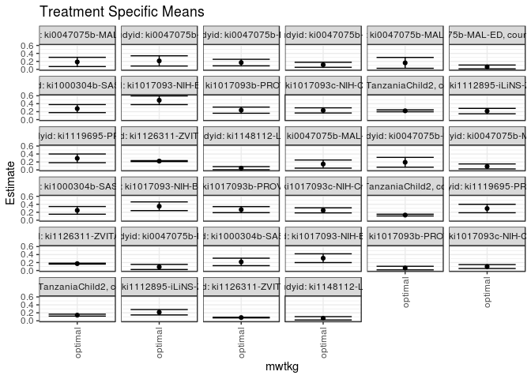

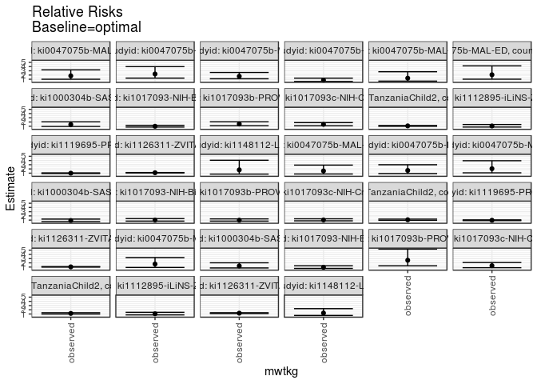

## Results Table

### Parameter: TSM

| agecat | studyid | country | intervention_level | baseline_level | estimate | ci_lower | ci_upper |
| --- | --- | --- | --- | --- | --- | --- | --- |
| 0-24 months | ki0047075b-MAL-ED | BANGLADESH | optimal | NA | 0.1857733 | 0.0698753 | 0.3016712 |
| 0-24 months | ki0047075b-MAL-ED | INDIA | optimal | NA | 0.2116335 | 0.0831061 | 0.3401609 |
| 0-24 months | ki0047075b-MAL-ED | NEPAL | optimal | NA | 0.1700638 | 0.0876408 | 0.2524867 |
| 0-24 months | ki0047075b-MAL-ED | PERU | optimal | NA | 0.1143882 | 0.0512183 | 0.1775580 |
| 0-24 months | ki0047075b-MAL-ED | SOUTH AFRICA | optimal | NA | 0.1626067 | 0.0263158 | 0.2988976 |
| 0-24 months | ki0047075b-MAL-ED | TANZANIA, UNITED REPUBLIC OF | optimal | NA | 0.0606278 | 0.0127901 | 0.1084655 |
| 0-24 months | ki1000304b-SAS-CompFeed | INDIA | optimal | NA | 0.2770441 | 0.1757300 | 0.3783582 |
| 0-24 months | ki1017093-NIH-Birth | BANGLADESH | optimal | NA | 0.4863764 | 0.3775597 | 0.5951932 |
| 0-24 months | ki1017093b-PROVIDE | BANGLADESH | optimal | NA | 0.2377231 | 0.1605457 | 0.3149006 |
| 0-24 months | ki1017093c-NIH-Crypto | BANGLADESH | optimal | NA | 0.2313735 | 0.1663932 | 0.2963537 |
| 0-24 months | ki1066203-TanzaniaChild2 | TANZANIA, UNITED REPUBLIC OF | optimal | NA | 0.2211816 | 0.1967956 | 0.2455675 |
| 0-24 months | ki1112895-iLiNS-Zinc | BURKINA FASO | optimal | NA | 0.2146724 | 0.1469942 | 0.2823506 |
| 0-24 months | ki1119695-PROBIT | BELARUS | optimal | NA | 0.2909422 | 0.1818218 | 0.4000627 |
| 0-24 months | ki1126311-ZVITAMBO | ZIMBABWE | optimal | NA | 0.2216890 | 0.2096727 | 0.2337054 |
| 0-24 months | ki1148112-LCNI-5 | MALAWI | optimal | NA | 0.0443312 | 0.0061069 | 0.0825555 |
| 0-6 months | ki0047075b-MAL-ED | BANGLADESH | optimal | NA | 0.1469613 | 0.0450475 | 0.2488751 |
| 0-6 months | ki0047075b-MAL-ED | INDIA | optimal | NA | 0.1919063 | 0.0682776 | 0.3155350 |
| 0-6 months | ki0047075b-MAL-ED | NEPAL | optimal | NA | 0.0876193 | 0.0247193 | 0.1505193 |
| 0-6 months | ki1000304b-SAS-CompFeed | INDIA | optimal | NA | 0.2471813 | 0.1505007 | 0.3438618 |
| 0-6 months | ki1017093-NIH-Birth | BANGLADESH | optimal | NA | 0.3505982 | 0.2410180 | 0.4601783 |
| 0-6 months | ki1017093b-PROVIDE | BANGLADESH | optimal | NA | 0.2656487 | 0.1897432 | 0.3415543 |
| 0-6 months | ki1017093c-NIH-Crypto | BANGLADESH | optimal | NA | 0.2474638 | 0.1836385 | 0.3112891 |
| 0-6 months | ki1066203-TanzaniaChild2 | TANZANIA, UNITED REPUBLIC OF | optimal | NA | 0.1290114 | 0.1074437 | 0.1505791 |
| 0-6 months | ki1119695-PROBIT | BELARUS | optimal | NA | 0.2935586 | 0.1872189 | 0.3998983 |
| 0-6 months | ki1126311-ZVITAMBO | ZIMBABWE | optimal | NA | 0.1723983 | 0.1607398 | 0.1840567 |
| 6-24 months | ki0047075b-MAL-ED | NEPAL | optimal | NA | 0.0891921 | 0.0251017 | 0.1532825 |
| 6-24 months | ki1000304b-SAS-CompFeed | INDIA | optimal | NA | 0.2152649 | 0.1214489 | 0.3090809 |
| 6-24 months | ki1017093-NIH-Birth | BANGLADESH | optimal | NA | 0.3092270 | 0.1992269 | 0.4192271 |
| 6-24 months | ki1017093b-PROVIDE | BANGLADESH | optimal | NA | 0.0615210 | 0.0167765 | 0.1062656 |
| 6-24 months | ki1017093c-NIH-Crypto | BANGLADESH | optimal | NA | 0.0992499 | 0.0504328 | 0.1480670 |
| 6-24 months | ki1066203-TanzaniaChild2 | TANZANIA, UNITED REPUBLIC OF | optimal | NA | 0.1417164 | 0.1176536 | 0.1657791 |
| 6-24 months | ki1112895-iLiNS-Zinc | BURKINA FASO | optimal | NA | 0.2146724 | 0.1469942 | 0.2823506 |
| 6-24 months | ki1126311-ZVITAMBO | ZIMBABWE | optimal | NA | 0.0812062 | 0.0730315 | 0.0893809 |
| 6-24 months | ki1148112-LCNI-5 | MALAWI | optimal | NA | 0.0625887 | 0.0207678 | 0.1044096 |

### Parameter: E(Y)

| agecat | studyid | country | intervention_level | baseline_level | estimate | ci_lower | ci_upper |
| --- | --- | --- | --- | --- | --- | --- | --- |
| 0-24 months | ki0047075b-MAL-ED | BANGLADESH | observed | NA | 0.3346457 | 0.2765014 | 0.3927899 |
| 0-24 months | ki0047075b-MAL-ED | INDIA | observed | NA | 0.4752066 | 0.4121581 | 0.5382551 |
| 0-24 months | ki0047075b-MAL-ED | NEPAL | observed | NA | 0.2899160 | 0.2321510 | 0.3476810 |
| 0-24 months | ki0047075b-MAL-ED | PERU | observed | NA | 0.0896552 | 0.0567177 | 0.1225926 |
| 0-24 months | ki0047075b-MAL-ED | SOUTH AFRICA | observed | NA | 0.2037037 | 0.1555745 | 0.2518329 |
| 0-24 months | ki0047075b-MAL-ED | TANZANIA, UNITED REPUBLIC OF | observed | NA | 0.1250000 | 0.0844083 | 0.1655917 |
| 0-24 months | ki1000304b-SAS-CompFeed | INDIA | observed | NA | 0.3847826 | 0.3023315 | 0.4672337 |
| 0-24 months | ki1017093-NIH-Birth | BANGLADESH | observed | NA | 0.4775641 | 0.4383415 | 0.5167867 |
| 0-24 months | ki1017093b-PROVIDE | BANGLADESH | observed | NA | 0.3602392 | 0.3238339 | 0.3966444 |
| 0-24 months | ki1017093c-NIH-Crypto | BANGLADESH | observed | NA | 0.3311258 | 0.2975342 | 0.3647175 |
| 0-24 months | ki1066203-TanzaniaChild2 | TANZANIA, UNITED REPUBLIC OF | observed | NA | 0.2372449 | 0.2200495 | 0.2544403 |
| 0-24 months | ki1112895-iLiNS-Zinc | BURKINA FASO | observed | NA | 0.2259307 | 0.1907517 | 0.2611097 |
| 0-24 months | ki1119695-PROBIT | BELARUS | observed | NA | 0.2874385 | 0.1857322 | 0.3891448 |
| 0-24 months | ki1126311-ZVITAMBO | ZIMBABWE | observed | NA | 0.2438216 | 0.2358577 | 0.2517856 |
| 0-24 months | ki1148112-LCNI-5 | MALAWI | observed | NA | 0.0787590 | 0.0605107 | 0.0970072 |
| 0-6 months | ki0047075b-MAL-ED | BANGLADESH | observed | NA | 0.2244094 | 0.1730022 | 0.2758167 |
| 0-6 months | ki0047075b-MAL-ED | INDIA | observed | NA | 0.3140496 | 0.2554513 | 0.3726479 |
| 0-6 months | ki0047075b-MAL-ED | NEPAL | observed | NA | 0.1806723 | 0.1316889 | 0.2296556 |
| 0-6 months | ki1000304b-SAS-CompFeed | INDIA | observed | NA | 0.2222222 | 0.1648972 | 0.2795472 |
| 0-6 months | ki1017093-NIH-Birth | BANGLADESH | observed | NA | 0.3569132 | 0.3192325 | 0.3945938 |
| 0-6 months | ki1017093b-PROVIDE | BANGLADESH | observed | NA | 0.2630792 | 0.2296894 | 0.2964690 |
| 0-6 months | ki1017093c-NIH-Crypto | BANGLADESH | observed | NA | 0.2582781 | 0.2270370 | 0.2895193 |
| 0-6 months | ki1066203-TanzaniaChild2 | TANZANIA, UNITED REPUBLIC OF | observed | NA | 0.1403061 | 0.1262673 | 0.1543450 |
| 0-6 months | ki1119695-PROBIT | BELARUS | observed | NA | 0.2822232 | 0.1798711 | 0.3845754 |
| 0-6 months | ki1126311-ZVITAMBO | ZIMBABWE | observed | NA | 0.1803706 | 0.1732226 | 0.1875186 |
| 6-24 months | ki0047075b-MAL-ED | NEPAL | observed | NA | 0.1531915 | 0.1070438 | 0.1993392 |
| 6-24 months | ki1000304b-SAS-CompFeed | INDIA | observed | NA | 0.2714617 | 0.2176472 | 0.3252763 |
| 6-24 months | ki1017093-NIH-Birth | BANGLADESH | observed | NA | 0.2939002 | 0.2554778 | 0.3323226 |
| 6-24 months | ki1017093b-PROVIDE | BANGLADESH | observed | NA | 0.1612378 | 0.1321259 | 0.1903497 |
| 6-24 months | ki1017093c-NIH-Crypto | BANGLADESH | observed | NA | 0.1315068 | 0.1069744 | 0.1560393 |
| 6-24 months | ki1066203-TanzaniaChild2 | TANZANIA, UNITED REPUBLIC OF | observed | NA | 0.1612740 | 0.1450620 | 0.1774860 |
| 6-24 months | ki1112895-iLiNS-Zinc | BURKINA FASO | observed | NA | 0.2259307 | 0.1907517 | 0.2611097 |
| 6-24 months | ki1126311-ZVITAMBO | ZIMBABWE | observed | NA | 0.0973196 | 0.0914209 | 0.1032182 |
| 6-24 months | ki1148112-LCNI-5 | MALAWI | observed | NA | 0.0764563 | 0.0583018 | 0.0946108 |

### Parameter: RR

| agecat | studyid | country | intervention_level | baseline_level | estimate | ci_lower | ci_upper |
| --- | --- | --- | --- | --- | --- | --- | --- |
| 0-24 months | ki0047075b-MAL-ED | BANGLADESH | observed | optimal | 1.8013662 | 1.0042571 | 3.231165 |
| 0-24 months | ki0047075b-MAL-ED | INDIA | observed | optimal | 2.2454224 | 1.2626487 | 3.993131 |
| 0-24 months | ki0047075b-MAL-ED | NEPAL | observed | optimal | 1.7047486 | 1.1112949 | 2.615118 |
| 0-24 months | ki0047075b-MAL-ED | PERU | observed | optimal | 0.7837800 | 0.4886747 | 1.257096 |
| 0-24 months | ki0047075b-MAL-ED | SOUTH AFRICA | observed | optimal | 1.2527387 | 0.5641151 | 2.781975 |
| 0-24 months | ki0047075b-MAL-ED | TANZANIA, UNITED REPUBLIC OF | observed | optimal | 2.0617607 | 1.0176421 | 4.177163 |
| 0-24 months | ki1000304b-SAS-CompFeed | INDIA | observed | optimal | 1.3888859 | 0.9466630 | 2.037688 |
| 0-24 months | ki1017093-NIH-Birth | BANGLADESH | observed | optimal | 0.9818817 | 0.7966568 | 1.210172 |
| 0-24 months | ki1017093b-PROVIDE | BANGLADESH | observed | optimal | 1.5153728 | 1.1197294 | 2.050812 |
| 0-24 months | ki1017093c-NIH-Crypto | BANGLADESH | observed | optimal | 1.4311312 | 1.1075008 | 1.849332 |
| 0-24 months | ki1066203-TanzaniaChild2 | TANZANIA, UNITED REPUBLIC OF | observed | optimal | 1.0726250 | 0.9886792 | 1.163698 |
| 0-24 months | ki1112895-iLiNS-Zinc | BURKINA FASO | observed | optimal | 1.0524438 | 0.7907132 | 1.400809 |
| 0-24 months | ki1119695-PROBIT | BELARUS | observed | optimal | 0.9879575 | 0.9155353 | 1.066108 |
| 0-24 months | ki1126311-ZVITAMBO | ZIMBABWE | observed | optimal | 1.0998362 | 1.0538274 | 1.147854 |
| 0-24 months | ki1148112-LCNI-5 | MALAWI | observed | optimal | 1.7766025 | 0.7763877 | 4.065387 |
| 0-6 months | ki0047075b-MAL-ED | BANGLADESH | observed | optimal | 1.5269968 | 0.8007321 | 2.911984 |
| 0-6 months | ki0047075b-MAL-ED | INDIA | observed | optimal | 1.6364737 | 0.8940973 | 2.995252 |
| 0-6 months | ki0047075b-MAL-ED | NEPAL | observed | optimal | 2.0620149 | 1.0758228 | 3.952236 |
| 0-6 months | ki1000304b-SAS-CompFeed | INDIA | observed | optimal | 0.8990253 | 0.6510694 | 1.241414 |
| 0-6 months | ki1017093-NIH-Birth | BANGLADESH | observed | optimal | 1.0180121 | 0.7629239 | 1.358391 |
| 0-6 months | ki1017093b-PROVIDE | BANGLADESH | observed | optimal | 0.9903274 | 0.7621362 | 1.286841 |
| 0-6 months | ki1017093c-NIH-Crypto | BANGLADESH | observed | optimal | 1.0437009 | 0.8314137 | 1.310192 |
| 0-6 months | ki1066203-TanzaniaChild2 | TANZANIA, UNITED REPUBLIC OF | observed | optimal | 1.0875481 | 0.9568499 | 1.236099 |
| 0-6 months | ki1119695-PROBIT | BELARUS | observed | optimal | 0.9613863 | 0.8772192 | 1.053629 |
| 0-6 months | ki1126311-ZVITAMBO | ZIMBABWE | observed | optimal | 1.0462439 | 0.9910266 | 1.104538 |
| 6-24 months | ki0047075b-MAL-ED | NEPAL | observed | optimal | 1.7175457 | 0.9059543 | 3.256194 |
| 6-24 months | ki1000304b-SAS-CompFeed | INDIA | observed | optimal | 1.2610590 | 0.7907622 | 2.011059 |
| 6-24 months | ki1017093-NIH-Birth | BANGLADESH | observed | optimal | 0.9504351 | 0.6850074 | 1.318711 |
| 6-24 months | ki1017093b-PROVIDE | BANGLADESH | observed | optimal | 2.6208561 | 1.3035101 | 5.269531 |
| 6-24 months | ki1017093c-NIH-Crypto | BANGLADESH | observed | optimal | 1.3250076 | 0.8465126 | 2.073974 |
| 6-24 months | ki1066203-TanzaniaChild2 | TANZANIA, UNITED REPUBLIC OF | observed | optimal | 1.1380057 | 0.9936207 | 1.303371 |
| 6-24 months | ki1112895-iLiNS-Zinc | BURKINA FASO | observed | optimal | 1.0524438 | 0.7907132 | 1.400809 |
| 6-24 months | ki1126311-ZVITAMBO | ZIMBABWE | observed | optimal | 1.1984252 | 1.1053183 | 1.299375 |
| 6-24 months | ki1148112-LCNI-5 | MALAWI | observed | optimal | 1.2215674 | 0.6554452 | 2.276661 |

### Parameter: PAR

| agecat | studyid | country | intervention_level | baseline_level | estimate | ci_lower | ci_upper |
| --- | --- | --- | --- | --- | --- | --- | --- |
| 0-24 months | ki0047075b-MAL-ED | BANGLADESH | optimal | NA | 0.1488724 | 0.0394914 | 0.2582534 |
| 0-24 months | ki0047075b-MAL-ED | INDIA | optimal | NA | 0.2635731 | 0.1412577 | 0.3858885 |
| 0-24 months | ki0047075b-MAL-ED | NEPAL | optimal | NA | 0.1198522 | 0.0448931 | 0.1948113 |
| 0-24 months | ki0047075b-MAL-ED | PERU | optimal | NA | -0.0247330 | -0.0781415 | 0.0286755 |
| 0-24 months | ki0047075b-MAL-ED | SOUTH AFRICA | optimal | NA | 0.0410970 | -0.0887370 | 0.1709310 |
| 0-24 months | ki0047075b-MAL-ED | TANZANIA, UNITED REPUBLIC OF | optimal | NA | 0.0643722 | 0.0175011 | 0.1112433 |
| 0-24 months | ki1000304b-SAS-CompFeed | INDIA | optimal | NA | 0.1077385 | -0.0087720 | 0.2242490 |
| 0-24 months | ki1017093-NIH-Birth | BANGLADESH | optimal | NA | -0.0088123 | -0.1104821 | 0.0928574 |
| 0-24 months | ki1017093b-PROVIDE | BANGLADESH | optimal | NA | 0.1225160 | 0.0502582 | 0.1947739 |
| 0-24 months | ki1017093c-NIH-Crypto | BANGLADESH | optimal | NA | 0.0997523 | 0.0401321 | 0.1593726 |
| 0-24 months | ki1066203-TanzaniaChild2 | TANZANIA, UNITED REPUBLIC OF | optimal | NA | 0.0160633 | -0.0019736 | 0.0341002 |
| 0-24 months | ki1112895-iLiNS-Zinc | BURKINA FASO | optimal | NA | 0.0112582 | -0.0502791 | 0.0727956 |
| 0-24 months | ki1119695-PROBIT | BELARUS | optimal | NA | -0.0035037 | -0.0259091 | 0.0189018 |
| 0-24 months | ki1126311-ZVITAMBO | ZIMBABWE | optimal | NA | 0.0221326 | 0.0126434 | 0.0316218 |
| 0-24 months | ki1148112-LCNI-5 | MALAWI | optimal | NA | 0.0344277 | -0.0030350 | 0.0718904 |
| 0-6 months | ki0047075b-MAL-ED | BANGLADESH | optimal | NA | 0.0774481 | -0.0183713 | 0.1732676 |
| 0-6 months | ki0047075b-MAL-ED | INDIA | optimal | NA | 0.1221433 | 0.0053973 | 0.2388893 |
| 0-6 months | ki0047075b-MAL-ED | NEPAL | optimal | NA | 0.0930530 | 0.0319413 | 0.1541647 |
| 0-6 months | ki1000304b-SAS-CompFeed | INDIA | optimal | NA | -0.0249590 | -0.1042977 | 0.0543796 |
| 0-6 months | ki1017093-NIH-Birth | BANGLADESH | optimal | NA | 0.0063150 | -0.0947802 | 0.1074102 |
| 0-6 months | ki1017093b-PROVIDE | BANGLADESH | optimal | NA | -0.0025695 | -0.0721314 | 0.0669924 |
| 0-6 months | ki1017093c-NIH-Crypto | BANGLADESH | optimal | NA | 0.0108144 | -0.0454700 | 0.0670988 |
| 0-6 months | ki1066203-TanzaniaChild2 | TANZANIA, UNITED REPUBLIC OF | optimal | NA | 0.0112947 | -0.0051938 | 0.0277832 |
| 0-6 months | ki1119695-PROBIT | BELARUS | optimal | NA | -0.0113354 | -0.0380062 | 0.0153354 |
| 0-6 months | ki1126311-ZVITAMBO | ZIMBABWE | optimal | NA | 0.0079724 | -0.0013759 | 0.0173206 |
| 6-24 months | ki0047075b-MAL-ED | NEPAL | optimal | NA | 0.0639994 | 0.0045605 | 0.1234383 |
| 6-24 months | ki1000304b-SAS-CompFeed | INDIA | optimal | NA | 0.0561968 | -0.0488283 | 0.1612220 |
| 6-24 months | ki1017093-NIH-Birth | BANGLADESH | optimal | NA | -0.0153268 | -0.1166669 | 0.0860133 |
| 6-24 months | ki1017093b-PROVIDE | BANGLADESH | optimal | NA | 0.0997167 | 0.0536951 | 0.1457383 |
| 6-24 months | ki1017093c-NIH-Crypto | BANGLADESH | optimal | NA | 0.0322570 | -0.0123889 | 0.0769029 |
| 6-24 months | ki1066203-TanzaniaChild2 | TANZANIA, UNITED REPUBLIC OF | optimal | NA | 0.0195577 | 0.0002525 | 0.0388628 |
| 6-24 months | ki1112895-iLiNS-Zinc | BURKINA FASO | optimal | NA | 0.0112582 | -0.0502791 | 0.0727956 |
| 6-24 months | ki1126311-ZVITAMBO | ZIMBABWE | optimal | NA | 0.0161134 | 0.0094656 | 0.0227611 |
| 6-24 months | ki1148112-LCNI-5 | MALAWI | optimal | NA | 0.0138676 | -0.0252098 | 0.0529450 |

### Parameter: PAF

| agecat | studyid | country | intervention_level | baseline_level | estimate | ci_lower | ci_upper |
| --- | --- | --- | --- | --- | --- | --- | --- |
| 0-24 months | ki0047075b-MAL-ED | BANGLADESH | optimal | NA | 0.4448658 | 0.0042390 | 0.6905141 |
| 0-24 months | ki0047075b-MAL-ED | INDIA | optimal | NA | 0.5546495 | 0.2080141 | 0.7495700 |
| 0-24 months | ki0047075b-MAL-ED | NEPAL | optimal | NA | 0.4134032 | 0.1001489 | 0.6176081 |
| 0-24 months | ki0047075b-MAL-ED | PERU | optimal | NA | -0.2758683 | -1.0463511 | 0.2045159 |
| 0-24 months | ki0047075b-MAL-ED | SOUTH AFRICA | optimal | NA | 0.2017489 | -0.7726878 | 0.6405432 |
| 0-24 months | ki0047075b-MAL-ED | TANZANIA, UNITED REPUBLIC OF | optimal | NA | 0.5149777 | 0.0173362 | 0.7606031 |
| 0-24 months | ki1000304b-SAS-CompFeed | INDIA | optimal | NA | 0.2799984 | -0.0563421 | 0.5092478 |
| 0-24 months | ki1017093-NIH-Birth | BANGLADESH | optimal | NA | -0.0184527 | -0.2552456 | 0.1736710 |
| 0-24 months | ki1017093b-PROVIDE | BANGLADESH | optimal | NA | 0.3400964 | 0.1069271 | 0.5123883 |
| 0-24 months | ki1017093c-NIH-Crypto | BANGLADESH | optimal | NA | 0.3012521 | 0.0970661 | 0.4592642 |
| 0-24 months | ki1066203-TanzaniaChild2 | TANZANIA, UNITED REPUBLIC OF | optimal | NA | 0.0677077 | -0.0114504 | 0.1406707 |
| 0-24 months | ki1112895-iLiNS-Zinc | BURKINA FASO | optimal | NA | 0.0498305 | -0.2646811 | 0.2861267 |
| 0-24 months | ki1119695-PROBIT | BELARUS | optimal | NA | -0.0121893 | -0.0922572 | 0.0620092 |
| 0-24 months | ki1126311-ZVITAMBO | ZIMBABWE | optimal | NA | 0.0907737 | 0.0510780 | 0.1288088 |
| 0-24 months | ki1148112-LCNI-5 | MALAWI | optimal | NA | 0.4371279 | -0.2880163 | 0.7540209 |
| 0-6 months | ki0047075b-MAL-ED | BANGLADESH | optimal | NA | 0.3451198 | -0.2488572 | 0.6565916 |
| 0-6 months | ki0047075b-MAL-ED | INDIA | optimal | NA | 0.3889300 | -0.1184465 | 0.6661382 |
| 0-6 months | ki0047075b-MAL-ED | NEPAL | optimal | NA | 0.5150374 | 0.0704789 | 0.7469787 |
| 0-6 months | ki1000304b-SAS-CompFeed | INDIA | optimal | NA | -0.1123157 | -0.5359346 | 0.1944668 |
| 0-6 months | ki1017093-NIH-Birth | BANGLADESH | optimal | NA | 0.0176934 | -0.3107467 | 0.2638347 |
| 0-6 months | ki1017093b-PROVIDE | BANGLADESH | optimal | NA | -0.0097671 | -0.3121015 | 0.2229034 |
| 0-6 months | ki1017093c-NIH-Crypto | BANGLADESH | optimal | NA | 0.0418711 | -0.2027707 | 0.2367531 |
| 0-6 months | ki1066203-TanzaniaChild2 | TANZANIA, UNITED REPUBLIC OF | optimal | NA | 0.0805005 | -0.0450960 | 0.1910031 |
| 0-6 months | ki1119695-PROBIT | BELARUS | optimal | NA | -0.0401646 | -0.1399660 | 0.0508994 |
| 0-6 months | ki1126311-ZVITAMBO | ZIMBABWE | optimal | NA | 0.0442000 | -0.0090546 | 0.0946439 |
| 6-24 months | ki0047075b-MAL-ED | NEPAL | optimal | NA | 0.4177738 | -0.1038085 | 0.6928930 |
| 6-24 months | ki1000304b-SAS-CompFeed | INDIA | optimal | NA | 0.2070157 | -0.2646026 | 0.5027496 |
| 6-24 months | ki1017093-NIH-Birth | BANGLADESH | optimal | NA | -0.0521497 | -0.4598382 | 0.2416838 |
| 6-24 months | ki1017093b-PROVIDE | BANGLADESH | optimal | NA | 0.6184453 | 0.2328406 | 0.8102298 |
| 6-24 months | ki1017093c-NIH-Crypto | BANGLADESH | optimal | NA | 0.2452874 | -0.1813173 | 0.5178339 |
| 6-24 months | ki1066203-TanzaniaChild2 | TANZANIA, UNITED REPUBLIC OF | optimal | NA | 0.1212697 | -0.0064203 | 0.2327591 |
| 6-24 months | ki1112895-iLiNS-Zinc | BURKINA FASO | optimal | NA | 0.0498305 | -0.2646811 | 0.2861267 |
| 6-24 months | ki1126311-ZVITAMBO | ZIMBABWE | optimal | NA | 0.1655716 | 0.0952833 | 0.2303992 |
| 6-24 months | ki1148112-LCNI-5 | MALAWI | optimal | NA | 0.1813796 | -0.5256805 | 0.5607603 |